# Homework 2

Divij Nandan Sharma

2024-05-22

```
## Rows: 671,028
## Columns: 14
## $ trans_date_trans_time <dttm> 2019-02-22 07:32:58, 2019-02-16 15:07:20, 2019-…
## $ trans_year            <dbl> 2019, 2019, 2019, 2019, 2019, 2019, 2019, 2020, …
## $ category              <chr> "entertainment", "kids_pets", "personal_care", "…
## $ amt                   <dbl> 7.79, 3.89, 8.43, 40.00, 54.04, 95.61, 64.95, 3.…
## $ city                  <chr> "Veedersburg", "Holloway", "Arnold", "Apison", "…
## $ state                 <chr> "IN", "OH", "MO", "TN", "CO", "GA", "MN", "AL", …
## $ lat                   <dbl> 40.1186, 40.0113, 38.4305, 35.0149, 39.4584, 32.…
## $ long                  <dbl> -87.2602, -80.9701, -90.3870, -85.0164, -106.385…
## $ city_pop              <dbl> 4049, 128, 35439, 3730, 277, 1841, 136, 190178, …
## $ job                   <chr> "Development worker, community", "Child psychoth…
## $ dob                   <date> 1959-10-19, 1946-04-03, 1985-03-31, 1991-01-28,…
## $ merch_lat             <dbl> 39.41679, 39.74585, 37.73078, 34.53277, 39.95244…
## $ merch_long            <dbl> -87.52619, -81.52477, -91.36875, -84.10676, -106…
## $ is_fraud              <dbl> 0, 0, 0, 0, 0, 0, 0, 0, 0, 0, 0, 0, 0, 0, 0, 0, …
```

The data dictionary is as follows

| column(variable) | description |
| --- | --- |
| trans_date_trans_time | Transaction DateTime |
| trans_year | Transaction year |
| category | category of merchant |
| amt | amount of transaction |
| city | City of card holder |
| state | State of card holder |
| lat | Latitude location of purchase |
| long | Longitude location of purchase |
| city_pop | card holder’s city population |
| job | job of card holder |
| dob | date of birth of card holder |
| merch_lat | Latitude Location of Merchant |
| merch_long | Longitude Location of Merchant |
| is_fraud | Whether Transaction is Fraud (1) or Not (0) |

- In this dataset, how likely are fraudulent transactions? Generate a table that summarizes the number and frequency of fraudulent transactions per year.

```r
# Convert transaction date-time to Date type and extract the year
card_fraud_clean <- card_fraud %>%
  mutate(trans_year = lubridate::year(lubridate::ymd_hms(trans_date_trans_time)))
# Summarize the number and frequency of fraudulent transactions by year
fraud_summary <- card_fraud_clean %>%
  group_by(trans_year) %>%
  summarise(
    total_transactions = n(),
    fraud_transactions = sum(is_fraud),
    fraud_frequency = fraud_transactions / total_transactions
  )

# View the summary
print(fraud_summary)
```

```
## # A tibble: 3 × 4
##   trans_year total_transactions fraud_transactions fraud_frequency
##        <dbl>              <int>              <dbl>           <dbl>
## 1       2019             478642               2721         0.00568
## 2       2020             192380               1215         0.00632
## 3         NA                  6                  0         0
```

- How much money (in US$ terms) are fraudulent transactions costing the company? Generate a table that summarizes the total amount of legitimate and fraudulent transactions per year and calculate the % of fraudulent transactions, in US$ terms.

```r
# Ensure the amount is treated as numeric if not already
card_fraud_clean$amt <- as.numeric(card_fraud_clean$amt)

# Convert transaction date-time to Date type and extract the year if not already
card_fraud_clean <- card_fraud_clean %>%
  mutate(trans_year = lubridate::year(lubridate::ymd_hms(trans_date_trans_time)))
# Summarize the total amount of legitimate and fraudulent transactions by year
amount_summary <- card_fraud_clean %>%
  group_by(trans_year) %>%
  summarise(
    total_amt = sum(amt),
    fraud_amt = sum(amt[is_fraud == 1]),
    legit_amt = sum(amt[is_fraud == 0]),
    fraud_percentage = (fraud_amt / total_amt) * 100
  )

# View the summary
print(amount_summary)
```

```
## # A tibble: 3 × 5
##   trans_year total_amt fraud_amt legit_amt fraud_percentage
##        <dbl>     <dbl>     <dbl>     <dbl>            <dbl>
## 1       2019 33605617.  1423140. 32182477.             4.23
## 2       2020 13577697.   651949. 12925748.             4.80
## 3         NA      590.        0       590.             0
```

- Generate a histogram that shows the distribution of amounts charged to credit card, both for legitimate and fraudulent accounts. Also, for both types of transactions, calculate some quick summary statistics.

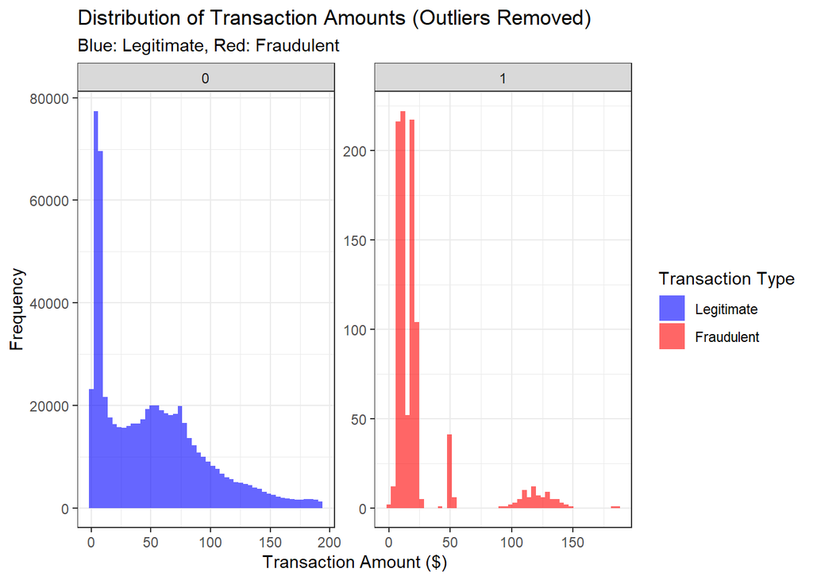

```r
# There are a few very large transactions that affect how the histogram displays, I will first remove the outliers then create the histogram so that it displays properly
# Calculate the interquartile range (IQR) for transaction amounts
iqr_values <- card_fraud_clean %>%
  summarise(
    Q1 = quantile(amt, 0.25),
    Q3 = quantile(amt, 0.75)
  ) %>%
  mutate(IQR = Q3 - Q1, Lower_Bound = Q1 - 1.5 * IQR, Upper_Bound = Q3 + 1.5 * IQR)

# Filter out outlier transaction amounts beyond the lower and upper bounds
filtered_data <- card_fraud_clean %>%
  filter(amt >= iqr_values$Lower_Bound & amt <= iqr_values$Upper_Bound)

# Histogram of transaction amounts for the filtered data
ggplot(filtered_data, aes(x = amt, fill = factor(is_fraud))) +
  geom_histogram(bins = 50, alpha = 0.6, position = "identity") +
  scale_fill_manual(values = c("blue", "red"), labels = c("Legitimate", "Fraudulent")) +

# Display legit and fraud transactions separately to account for different frequencies and adjust the scale accordingly
  facet_wrap(~is_fraud, scales = "free") +
  labs(fill = "Transaction Type",
       x = "Transaction Amount ($)",
       y = "Frequency",
       title = "Distribution of Transaction Amounts (Outliers Removed)",
       subtitle = "Blue: Legitimate, Red: Fraudulent") +
  theme_bw() +
  NULL
```

```r
# Print the bounds used to filter outliers
print(paste("Lower Bound:", iqr_values$Lower_Bound, "Upper Bound:", iqr_values$Upper_Bound))
```

```
## [1] "Lower Bound: -100.415 Upper Bound: 193.065"
```

```r
# Calculate summary statistics for both legitimate and fraudulent transactions
summary_stats <- card_fraud_clean %>%
  group_by(is_fraud) %>%
  summarise(
    Count = n(),
    Mean = mean(amt),
    Median = median(amt),
    Min = min(amt),
    Max = max(amt),
    SD = sd(amt)
  )

# View the summary statistics
print(summary_stats)
```

```
## # A tibble: 2 × 7
##   is_fraud  Count  Mean Median   Min    Max    SD
##      <dbl>  <int> <dbl>  <dbl> <dbl>  <dbl> <dbl>
## 1        0 667092  67.6   47.2  1    27120.  155.
## 2        1   3936 527.   369.   1.06  1334.  391.
```

- What types of purchases are most likely to be instances of fraud? Consider category of merchants and produce a bar chart that shows % of total fraudulent transactions sorted in order.

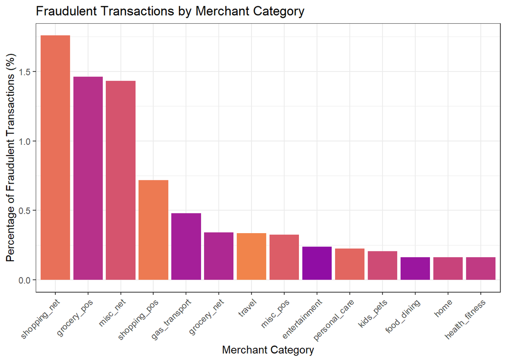

```r
# Calculate the percentage of fraudulent transactions by category
fraud_by_category <- card_fraud_clean %>%
  group_by(category) %>%
  summarise(
    Total_Transactions = n(),
    Fraud_Transactions = sum(is_fraud),
    Fraud_Percentage = (Fraud_Transactions / Total_Transactions) * 100
  ) %>%
  arrange(desc(Fraud_Percentage)) # Sort by descending order of fraud percentage

# Bar chart of the percentage of fraudulent transactions by merchant category
ggplot(fraud_by_category, aes(x = reorder(category, -Fraud_Percentage), y = Fraud_Percentage, fill = category)) +
  geom_bar(stat = "identity") +
  labs(x = "Merchant Category", y = "Percentage of Fraudulent Transactions (%)",
       title = "Fraudulent Transactions by Merchant Category") +
  theme_bw() +
  theme(axis.text.x = element_text(angle = 45, hjust = 1)) +
  scale_fill_viridis_d(begin = 0.3, end = 0.7, direction = 1, option = "C", guide = "none") + # Color scale for better visual distinction
  NULL
```

```r
# Print the table of fraud percentages by category
print(fraud_by_category)
```

```
## # A tibble: 14 × 4
##    category       Total_Transactions Fraud_Transactions Fraud_Percentage
##    <chr>                       <int>              <dbl>            <dbl>
##  1 shopping_net                50743                892            1.76
##  2 grocery_pos                 63791                932            1.46
##  3 misc_net                    32829                470            1.43
##  4 shopping_pos                60416                434            0.718
##  5 gas_transport               68046                326            0.479
##  6 grocery_net                 23485                 80            0.341
##  7 travel                      20873                 70            0.335
##  8 misc_pos                    41244                134            0.325
##  9 entertainment               48521                116            0.239
## 10 personal_care               46843                106            0.226
## 11 kids_pets                   58772                122            0.208
## 12 food_dining                 47527                 78            0.164
## 13 home                        63597                104            0.164
## 14 health_fitness              44341                 72            0.162
```

Most Likely Categories for Fraud: Shopping_net: Online shopping transactions are the most likely to be fraudulent. Grocery_pos: In-store grocery transactions also show a high likelihood of fraud. Misc_net: Miscellaneous online transactions have a similar high likelihood of fraud. Shopping_pos: In-store shopping transactions have a moderate likelihood of fraud. Gas_transport: Transactions related to transportation and gas have a notable likelihood of fraud.

- When is fraud more prevalent? Which days, months, hours?

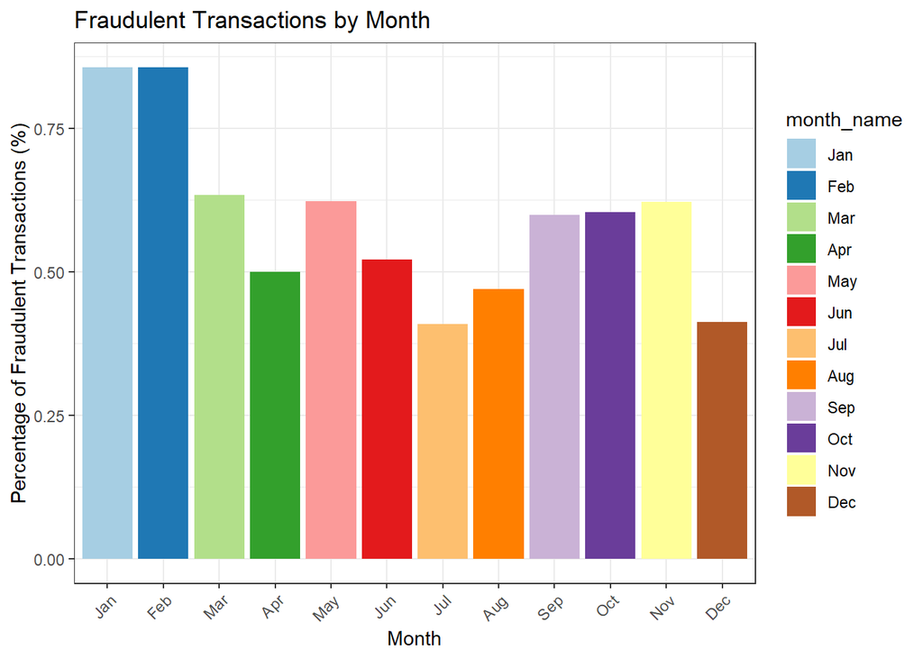

```r
# Enhance data with additional time components
card_fraud_clean <- card_fraud_clean %>%
  mutate(
    date_only = lubridate::date(trans_date_trans_time),
    month_name = lubridate::month(trans_date_trans_time, label = TRUE),
    hour = lubridate::hour(trans_date_trans_time),
    weekday = lubridate::wday(trans_date_trans_time, label = TRUE, week_start = 1)
  )

# Analyze fraud by month
fraud_by_month <- card_fraud_clean %>%
  group_by(month_name) %>%
  summarise(
    Total_Transactions = n(),
    Fraud_Transactions = sum(is_fraud),
    Fraud_Percentage = (Fraud_Transactions / Total_Transactions) * 100
  ) %>%
  arrange(desc(Fraud_Percentage))

# Plot fraud by month
ggplot(fraud_by_month, aes(x = month_name, y = Fraud_Percentage, fill = month_name)) +
  geom_bar(stat = "identity") +
  labs(x = "Month", y = "Percentage of Fraudulent Transactions (%)",
       title = "Fraudulent Transactions by Month") +
  theme_bw() +
  theme(axis.text.x = element_text(angle = 45, hjust = 1)) +
  scale_fill_brewer(palette = "Paired")
```

```r
  NULL
```

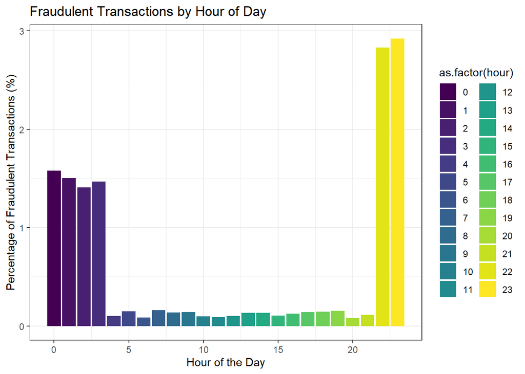

```r
# Analyze fraud by hour
fraud_by_hour <- card_fraud_clean %>%
  group_by(hour) %>%
  summarise(
    Total_Transactions = n(),
    Fraud_Transactions = sum(is_fraud),
    Fraud_Percentage = (Fraud_Transactions / Total_Transactions) * 100
  ) %>%
  arrange(desc(Fraud_Percentage))

# Plot fraud by hour
ggplot(fraud_by_hour, aes(x = hour, y = Fraud_Percentage, fill = as.factor(hour))) +
  geom_bar(stat = "identity") +
  labs(x = "Hour of the Day", y = "Percentage of Fraudulent Transactions (%)",
       title = "Fraudulent Transactions by Hour of Day") +
  theme_bw() +
  scale_fill_viridis_d() +
  NULL
```

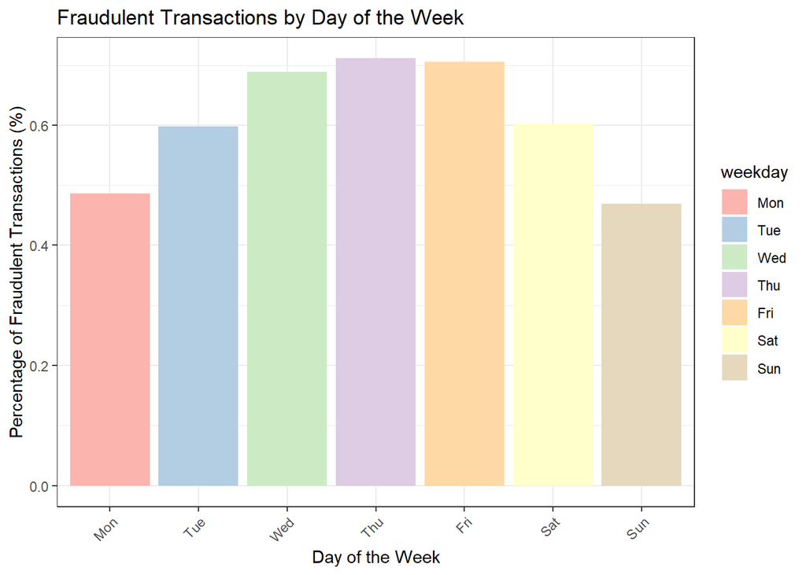

```r
# Analyze fraud by weekday
fraud_by_weekday <- card_fraud_clean %>%
  group_by(weekday) %>%
  summarise(
    Total_Transactions = n(),
    Fraud_Transactions = sum(is_fraud),
    Fraud_Percentage = (Fraud_Transactions / Total_Transactions) * 100
  ) %>%
  arrange(desc(Fraud_Percentage))

# Plot fraud by weekday
ggplot(fraud_by_weekday, aes(x = weekday, y = Fraud_Percentage, fill = weekday)) +
  geom_bar(stat = "identity") +
  labs(x = "Day of the Week", y = "Percentage of Fraudulent Transactions (%)",
       title = "Fraudulent Transactions by Day of the Week") +
  theme_bw() +
  theme(axis.text.x = element_text(angle = 45, hjust = 1)) +
  scale_fill_brewer(palette = "Pastel1") +
  NULL
```

- Are older customers significantly more likely to be victims of credit card fraud?

```r
# Calculate the age of customers at the time of transaction
card_fraud_clean <- card_fraud_clean %>%
  mutate(
    age = interval(dob, trans_date_trans_time) / years(1)
  )

# Summary statistics of age for fraudulent vs. non-fraudulent transactions
age_summary <- card_fraud_clean %>%
  group_by(is_fraud) %>%
  summarise(
    Mean_Age = mean(age, na.rm = TRUE),
    Median_Age = median(age, na.rm = TRUE),
    SD_Age = sd(age, na.rm = TRUE)
  )

# Print the summary statistics
print(age_summary)
```

```
## # A tibble: 2 × 4
##   is_fraud Mean_Age Median_Age SD_Age
##      <dbl>    <dbl>      <dbl>  <dbl>
## 1        0     46.0       43.9   17.4
## 2        1     49.0       48.3   19.0
```

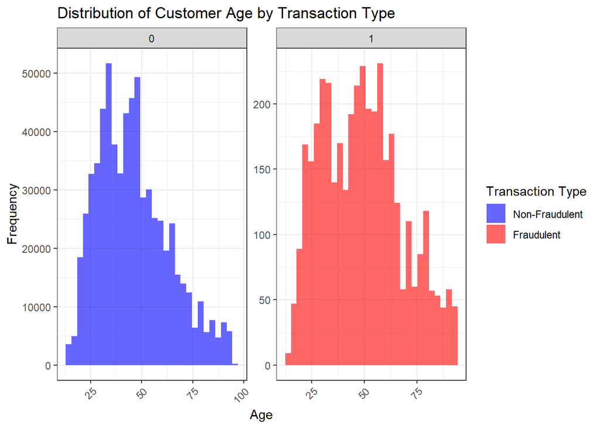

```r
# Optional: Visualizing the distribution of age for fraudulent vs non-fraudulent transactions
ggplot(card_fraud_clean, aes(x = age, fill = factor(is_fraud))) +
  geom_histogram(bins = 30, position = "identity", alpha = 0.6) +
  facet_wrap(~is_fraud, scales = "free") +
  scale_fill_manual(values = c("blue", "red"), labels = c("Non-Fraudulent", "Fraudulent")) +
  labs(x = "Age", y = "Frequency", fill = "Transaction Type",
       title = "Distribution of Customer Age by Transaction Type") +
  theme_bw() +
  theme(axis.text.x = element_text(angle = 45, hjust = 1)) +
  NULL
```

```r
# Conduct a t-test to see if the difference in mean ages between groups is statistically significant
t_test_result <- t.test(age ~ is_fraud, data = card_fraud_clean)

# Print t-test results
print(t_test_result)
```

```
##
##  Welch Two Sample t-test
##
## data:  age by is_fraud
## t = -10.04, df = 3974.1, p-value < 2.2e-16
## alternative hypothesis: true difference in means between group 0 and group 1 is not equal to 0
## 95 percent confidence interval:
##  -3.639299 -2.450144
## sample estimates:
## mean in group 0 mean in group 1
##        45.96697        49.01169
```

Yes, older customers are significantly more likely to be victims of credit card fraud. The histograms show a shift towards an older age group for fraudulent transactions, and the t-test confirms that the difference in mean ages between fraudulent and non-fraudulent transactions is statistically significant.

- Is fraud related to distance? The distance between a card holder’s home and the location of the transaction can be a feature that is related to fraud.

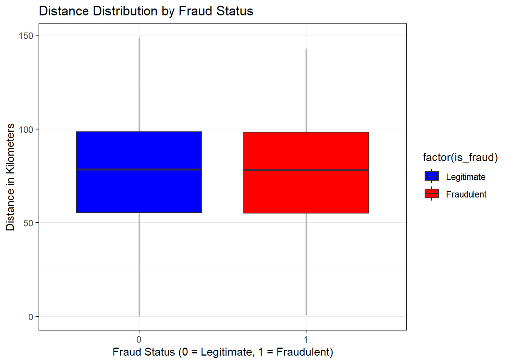

```r
# distance between card holder's home and transaction
# code adapted from https://www.geeksforgeeks.org/program-distance-two-points-earth/amp/


card_fraud <- card_fraud %>%
  mutate(

    # convert latitude/longitude to radians
    lat1_radians = lat / 57.29577951,
    lat2_radians = merch_lat / 57.29577951,
    long1_radians = long / 57.29577951,
    long2_radians = merch_long / 57.29577951,

    # calculate distance in miles
    distance_miles = 3963.0 * acos((sin(lat1_radians) * sin(lat2_radians)) + cos(lat1_radians) * cos(lat2_radians) * cos(long2_radians - long1_radians)),

    # calculate distance in km
    distance_km = 6377.830272 * acos((sin(lat1_radians) * sin(lat2_radians)) + cos(lat1_radians) * cos(lat2_radians) * cos(long2_radians - long1_radians))

  )

ggplot(card_fraud, aes(x = factor(is_fraud), y = distance_km, fill = factor(is_fraud))) +
  geom_boxplot() +
  labs(x = "Fraud Status (0 = Legitimate, 1 = Fraudulent)", y = "Distance in Kilometers",
       title = "Distance Distribution by Fraud Status") +
  theme_bw() +
  scale_fill_manual(values = c("blue", "red"), labels = c("Legitimate", "Fraudulent")) +
  NULL
```

```r
# T-test for comparing means (if the data is normally distributed)
t_test_results <- t.test(distance_km ~ is_fraud, data = card_fraud)

# Wilcoxon rank-sum test for comparing medians (if the data is not normally distributed)
wilcox_test_results <- wilcox.test(distance_km ~ is_fraud, data = card_fraud)

# Print the results
print(t_test_results)
```

```
##
##  Welch Two Sample t-test
##
## data:  distance_km by is_fraud
## t = -0.038854, df = 3982.5, p-value = 0.969
## alternative hypothesis: true difference in means between group 0 and group 1 is not equal to 0
## 95 percent confidence interval:
##  -0.9231984  0.8873184
## sample estimates:
## mean in group 0 mean in group 1
##        76.20257        76.22051
```

```r
print(wilcox_test_results)
```

```
##
##  Wilcoxon rank sum test with continuity correction
##
## data:  distance_km by is_fraud
## W = 1314768681, p-value = 0.8733
## alternative hypothesis: true location shift is not equal to 0
```

Plot a boxplot or a violin plot that looks at the relationship of distance and `is_fraud`. Does distance seem to be a useful feature in explaining fraud?

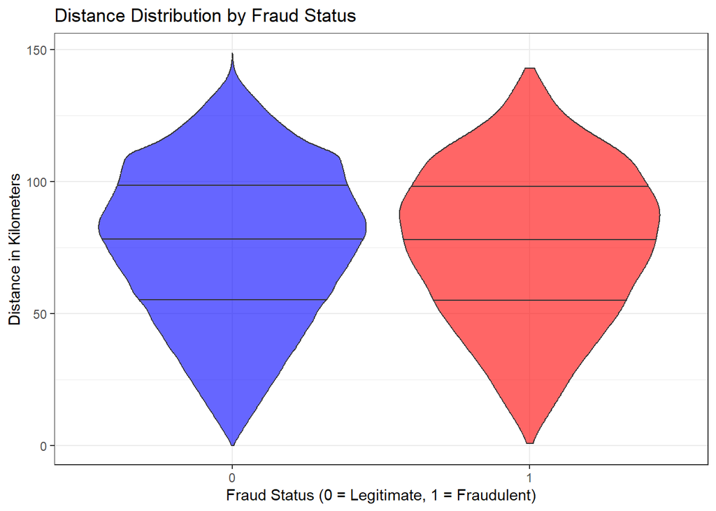

```r
# Violin plot
ggplot(card_fraud, aes(x = factor(is_fraud), y = distance_km, fill = factor(is_fraud))) +
  geom_violin(alpha = 0.6, draw_quantiles = c(0.25, 0.5, 0.75)) +
  labs(x = "Fraud Status (0 = Legitimate, 1 = Fraudulent)", y = "Distance in Kilometers",
       title = "Distance Distribution by Fraud Status") +
  theme_bw() +
  scale_fill_manual(values = c("blue", "red"), labels = c("Legitimate", "Fraudulent")) +
  theme(legend.position = "none")
```

Based on the boxplot and violin plot, distance does not appear to be a strong distinguishing feature between legit and fraudulent transactions. The medians, interquartile ranges, and overall distributions are very similar for both categories, indicating that distance alone is unlikely to be a useful feature in explaining or predicting fraud.

# 1 Exploring sources of electricity production, CO2 emissions, and GDP per capita.

```r
# Download electricity data
url <- "https://nyc3.digitaloceanspaces.com/owid-public/data/energy/owid-energy-data.csv"

energy <- read_csv(url) %>%
  filter(year >= 1990,
         country == "India") %>%
  drop_na(iso_code) %>%
  select(1:2,
         iso3c = iso_code,
         biofuel = biofuel_electricity,
         coal = coal_electricity,
         gas = gas_electricity,
         hydro = hydro_electricity,
         nuclear = nuclear_electricity,
         oil = oil_electricity,
         other_renewable = other_renewable_exc_biofuel_electricity,
         solar = solar_electricity,
         wind = wind_electricity,
         electricity_demand,
         electricity_generation,
         net_elec_imports,  # Net electricity imports, measured in terawatt-hours
         energy_per_capita, # Primary energy consumption per capita, measured in kilowatt-hours Calculated by Our World in Data based on BP Statistical Review of World Energy and EIA International Energy Data
         energy_per_gdp,    # Energy consumption per unit of GDP. This is measured in kilowatt-hours per 2011 international-$.
         per_capita_electricity, #  Electricity generation per capita, measured in kilowatt-hours
  )

# Download data for C02 emissions per capita https://data.worldbank.org/indicator/EN.ATM.CO2E.PC
co2_percap <- wb_data(country = "India",
                      indicator = "EN.ATM.CO2E.PC",
                      start_date = 1990,
                      end_date = 2022,
                      return_wide=FALSE) %>%
  filter(!is.na(value)) %>%
  #drop unwanted variables
  select(-c(unit, obs_status, footnote, last_updated)) %>%
  rename(year = date,
         co2percap = value)


# Download data for GDP per capita  https://data.worldbank.org/indicator/NY.GDP.PCAP.PP.KD
gdp_percap <- wb_data(country = "India",
                      indicator = "NY.GDP.PCAP.PP.KD",
                      start_date = 1990,
                      end_date = 2022,
                      return_wide=FALSE) %>%
  filter(!is.na(value)) %>%
  #drop unwanted variables
  select(-c(unit, obs_status, footnote, last_updated)) %>%
  rename(year = date,
         GDPpercap = value)
```

## 1.1 1. A stacked area chart that shows how your own country generated its electricity since 2000.

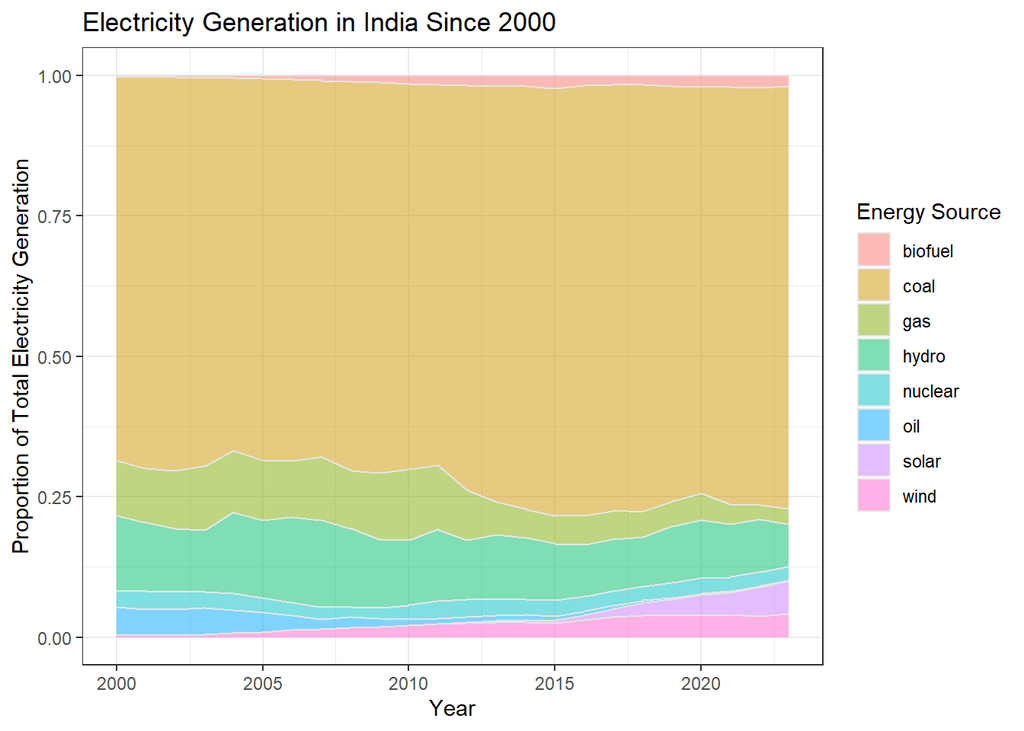

```r
# Filter data from the year 2000 onwards
energy_data_country <- energy %>%
  filter(year >= 2000) %>%
  select(year, biofuel, coal, gas, hydro, nuclear, oil, other_renewable, solar, wind)

# Transform data to long format for plotting
energy_data_long <- energy_data_country %>%
  pivot_longer(cols = -year, names_to = "source", values_to = "value")

# Create the stacked area chart
ggplot(energy_data_long, aes(x = year, y = value, fill = source)) +
  geom_area(colour = "grey90", alpha = 0.5, position = "fill") +
  labs(title = paste("Electricity Generation in India Since 2000"),
       x = "Year", y = "Proportion of Total Electricity Generation",
       fill = "Energy Source") +
  theme_bw()
```

## 1.2 2. A scatter plot that looks at how CO2 per capita and GDP per capita are related

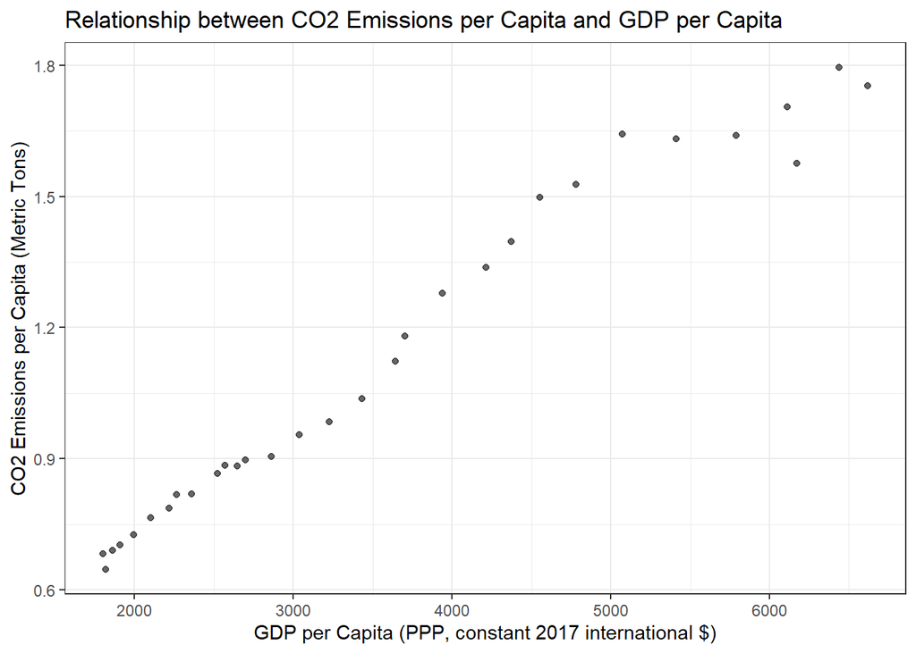

```r
# Merge energy, CO2 emissions, and GDP per capita datasets
merged_data <- energy %>%
  inner_join(co2_percap, by = c("iso3c", "year")) %>%
  inner_join(gdp_percap, by = c("iso3c", "year"))

# Create the scatter plot for CO2 emissions per capita and GDP per capita
ggplot(merged_data, aes(x = GDPpercap, y = co2percap)) +
  geom_point(alpha = 0.6) +
  labs(title = "Relationship between CO2 Emissions per Capita and GDP per Capita",
       x = "GDP per Capita (PPP, constant 2017 international $)",
       y = "CO2 Emissions per Capita (Metric Tons)") +
  theme_bw()
```

## 1.3 3. A scatter plot that looks at how electricity usage (kWh) per capita/day GDP per capita are related

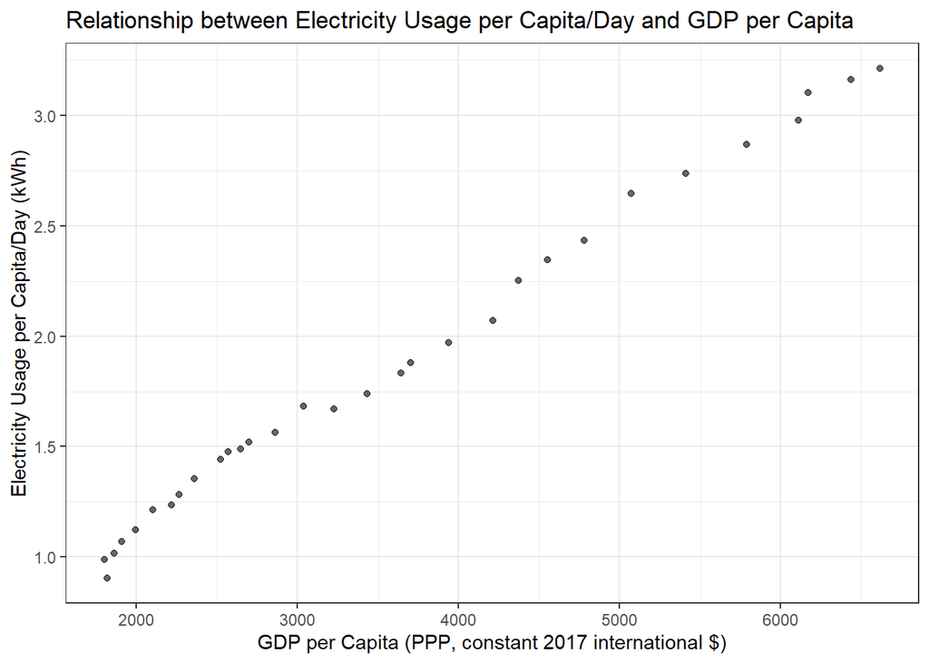

```r
# Merge energy, CO2 emissions, and GDP per capita datasets
merged_data <- energy %>%
  inner_join(co2_percap, by = c("iso3c", "year")) %>%
  inner_join(gdp_percap, by = c("iso3c", "year"))

# Convert electricity usage per capita from kWh/year to kWh/day
merged_data <- merged_data %>%
  mutate(electricity_per_capita_per_day = per_capita_electricity / 365)

# Create the scatter plot
ggplot(merged_data, aes(x = GDPpercap, y = electricity_per_capita_per_day)) +
  geom_point(alpha = 0.6) +
  labs(title = "Relationship between Electricity Usage per Capita/Day and GDP per Capita",
       x = "GDP per Capita (PPP, constant 2017 international $)",
       y = "Electricity Usage per Capita/Day (kWh)") +
  theme_bw()
```

Specific questions:

1. How would you turn `energy` to long, tidy format? A. I would use pivot_longer to convert the energy dataset from wide to long format. The cols argument specifies the columns to pivot (the different energy sources), names_to specifies the new column name for the energy source types, and values_to specifies the new column name for the values of electricity generated.
2. You may need to join these data frames
   - Use `left_join` from `dplyr` to [join the tables](http://r4ds.had.co.nz/relational-data.html)
   - To complete the merge, you need a unique *key* to match observations between the data frames. Country names may not be consistent among the three dataframes, so please use the 3-digit ISO code for each country
   - An aside: There is a great package called [`countrycode`](https://github.com/vincentarelbundock/countrycode) that helps solve the problem of inconsistent country names (Is it UK? United Kingdom? Great Britain?). `countrycode()` takes as an input a country’s name in a specific format and outputs it using whatever format you specify.
3. Write a function that takes as input any country’s name and returns all three graphs. You can use the `patchwork` package to arrange the three graphs as shown below

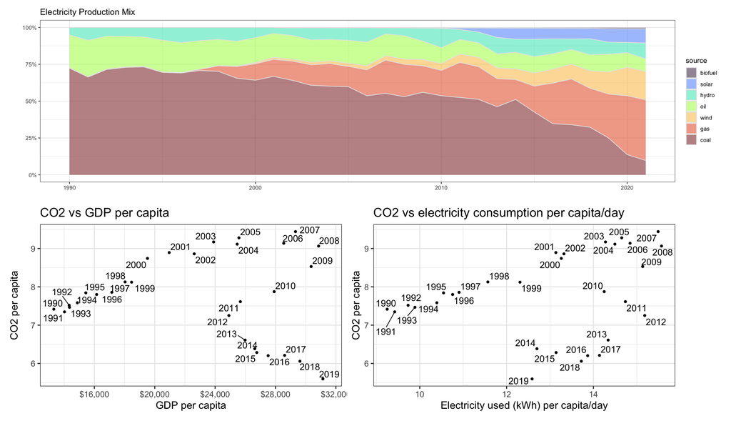

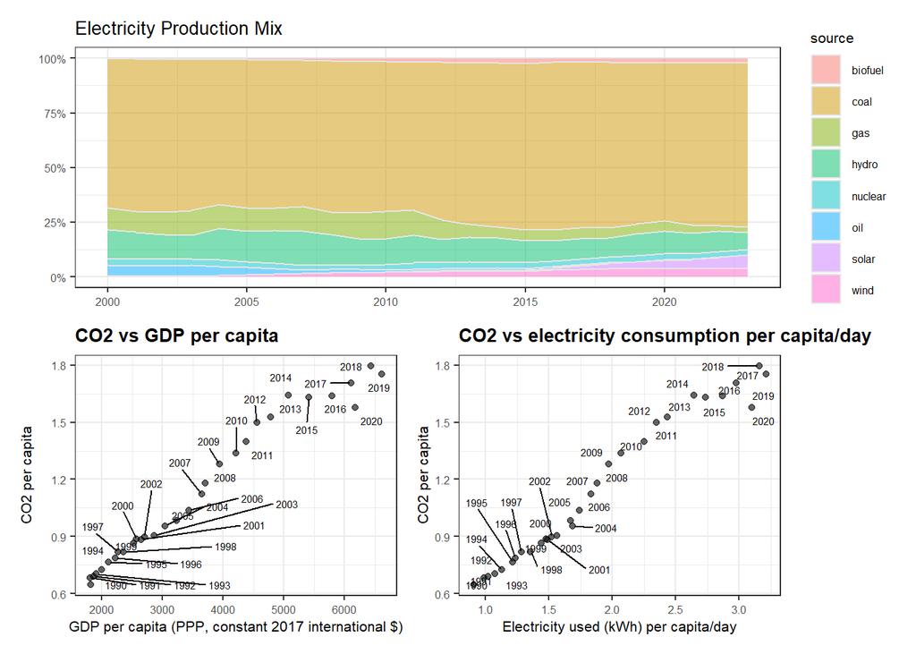

```r
# Function to generate and arrange the three plots
generate_country_plots <- function(country_name) {
  # Download and clean the electricity data
  url <- "https://nyc3.digitaloceanspaces.com/owid-public/data/energy/owid-energy-data.csv"

  energy <- read_csv(url, show_col_types = FALSE) %>%
    filter(year >= 1990) %>%
    drop_na(iso_code) %>%
    select(
      iso3c = iso_code,
      country,
      year,
      biofuel = biofuel_electricity,
      coal = coal_electricity,
      gas = gas_electricity,
      hydro = hydro_electricity,
      nuclear = nuclear_electricity,
      oil = oil_electricity,
      other_renewable = other_renewable_exc_biofuel_electricity,
      solar = solar_electricity,
      wind = wind_electricity,
      electricity_demand,
      electricity_generation,
      net_elec_imports,
      energy_per_capita,
      energy_per_gdp,
      per_capita_electricity
      )

  # Download and clean the CO2 emissions data
  co2_percap <- wb_data(country = country_name,
                        indicator = "EN.ATM.CO2E.PC",
                        start_date = 1990,
                        end_date = 2022,
                        return_wide = FALSE) %>%
    filter(!is.na(value)) %>%
    select(-c(unit, obs_status, footnote, last_updated)) %>%
    rename(year = date,
           co2percap = value)

  # Download and clean the GDP per capita data
  gdp_percap <- wb_data(country = country_name,
                        indicator = "NY.GDP.PCAP.PP.KD",
                        start_date = 1990,
                        end_date = 2022,
                        return_wide = FALSE) %>%
    filter(!is.na(value)) %>%
    select(-c(unit, obs_status, footnote, last_updated)) %>%
    rename(year = date,
           GDPpercap = value)

  # Filter data for the selected country
  energy_data_country <- energy %>%
    filter(country == country_name, year >= 2000) %>%
    select(year, biofuel, coal, gas, hydro, nuclear, oil, other_renewable, solar, wind)

  # Transform data to long format for plotting
  energy_data_long <- energy_data_country %>%
    pivot_longer(cols = -year, names_to = "source", values_to = "value")

  # Merge energy, CO2 emissions, and GDP per capita datasets
  merged_data <- energy %>%
    filter(country == country_name) %>%
    inner_join(co2_percap, by = c("iso3c", "year")) %>%
    inner_join(gdp_percap, by = c("iso3c", "year")) %>%
    mutate(electricity_per_capita_per_day = per_capita_electricity / 365)

  # Create the stacked area chart
  p1 <- ggplot(energy_data_long, aes(x = year, y = value, fill = source)) +
    geom_area(colour = "grey90", alpha = 0.5, position = "fill") +
    labs(title = "Electricity Production Mix",
         x = NULL, y = NULL,
         fill = "source") +
    scale_y_continuous( labels = scales::percent_format()) +
    theme_bw() +
    theme(
      plot.title = element_text(size = 10),
      legend.position = "right",
      legend.title = element_text(size = 8),
      legend.text = element_text(size = 6),
      axis.text = element_text(size = 6),
      axis.title = element_text(size = 8)
    )

  # Create the scatter plot for CO2 emissions per capita and GDP per capita
  p2 <- ggplot(merged_data, aes(x = GDPpercap, y = co2percap)) +
    geom_point(alpha = 0.6) +
    geom_text_repel(aes(label = year), size = 2, max.overlaps = 20) +
    labs(title = "CO2 vs GDP per capita",
         x = "GDP per capita (PPP, constant 2017 international $)",
         y = "CO2 per capita") +
    theme_bw() +
    theme(
      plot.title = element_text(size = 10, face = "bold"),
      axis.title = element_text(size = 8),
      axis.text = element_text(size = 6)
    )

  # Create the scatter plot for CO2 emissions per capita and electricity usage per capita/day
  p3 <- ggplot(merged_data, aes(x = electricity_per_capita_per_day, y = co2percap)) +
    geom_point(alpha = 0.6) +
    geom_text_repel(aes(label = year), size = 2, max.overlaps = 20) +
    labs(title = "CO2 vs electricity consumption per capita/day",
         x = "Electricity used (kWh) per capita/day",
         y = "CO2 per capita") +
    theme_bw() +
    theme(
      plot.title = element_text(size = 10, face = "bold"),
      axis.title = element_text(size = 8),
      axis.text = element_text(size = 6)
    )

  # Arrange the three plots using patchwork
  combined_plot <- p1 / (p2 | p3)

  return(combined_plot)
}

country_plots <- generate_country_plots("India")
ggsave("country_plots.png", plot = country_plots, width = 16, height = 9)
print(country_plots)
```

# 2 Deliverables

There is a lot of explanatory text, comments, etc. You do not need these, so delete them and produce a stand-alone document that you could share with someone. Knit the edited and completed R Markdown (qmd) file as a Word or HTML document (use the “Knit” button at the top of the script editor window) and upload it to Canvas. You must be comitting and pushing your changes to your own Github repo as you go along.

# 3 Details

**Please seek out help when you need it,** and remember the [15-minute rule](https://dsb2023.netlify.app/syllabus/#the-15-minute-rule). You know enough R (and have enough examples of code from class and your readings) to be able to do this. If you get stuck, ask for help from others, post a question on Slack– and remember that I am here to help too!

> As a true test to yourself, do you understand the code you submitted and are you able to explain it to someone else?

# 4 Rubric

13/13: Problem set is 100% completed. Every question was attempted and answered, and most answers are correct. Code is well-documented (both self-documented and with additional comments as necessary). Used tidyverse, instead of base R. Graphs and tables are properly labelled. Analysis is clear and easy to follow, either because graphs are labeled clearly or you’ve written additional text to describe how you interpret the output. Multiple Github commits. Work is exceptional. I will not assign these often.

8/13: Problem set is 60–80% complete and most answers are correct. This is the expected level of performance. Solid effort. Hits all the elements. No clear mistakes. Easy to follow (both the code and the output). A few Github commits.

5/13: Problem set is less than 60% complete and/or most answers are incorrect. This indicates that you need to improve next time. I will hopefully not assign these often. Displays minimal effort. Doesn’t complete all components. Code is poorly written and not documented. Uses the same type of plot for each graph, or doesn’t use plots appropriate for the variables being analyzed. No Github commits.